# Seed germination population threshold models

```r
library(tidyverse)
library(broom)
# Change some defaults for ggplot2
theme_set(theme_bw())
scale_colour_discrete <- function(...) scale_colour_brewer(palette = "Dark2")
scale_fill_discrete <- function(...) scale_fill_brewer(palette = "Dark2")
```

## Constant-time models

This is described in detail in [Bradford 1990](http://www.plantphysiol.org/content/94/2/840)

An essential component of the models is that the relationship between overcoming a threshold for germination and time is a constant:

$\theta = [X - X_b(c)]t_c$

Where:

- $\theta$ is the time constant for factor X
- $X$ is the value of X as perceived by the seed
- $X_b(c)$ is the threshold level of a particular seed $c$
- $t_c$ is the time that seed $c$ needs until germination

In practice, we control and therefore know (or assume to know):

- $t_c$ - this is the time at which we measure germination
- $X$ - this is the level of our factor (e.g. hormone concentration)

We want to estimate the properties of $X_b$, which is a distribution of seed thresholds in the population. Assuming that’s a normal distribution, we need to estimate:

- $\overline X_b$, the mean of the population threshold
- $\sigma _{X_b}$, the standard deviation of the population threshold

They give a relationship between all these variables in the following model:

$probit(g) = \frac{X - \frac{\theta}{t} - \overline X_b}{\sigma_{X_b}}$

By re-arranging the equation, it can be re-written as a more traditional linear model:

$probit(g) = \frac{1}{\sigma_{X_b}}X - \frac{1}{\sigma_{X_b}} \frac{\theta}{t} - \frac{1}{\sigma_{X_b}} X_b$

and a slight rearrangement:

$probit(g) = - \frac{1}{\sigma_{X_b}} X_b + \frac{1}{\sigma_{X_b}}X - \frac{\theta}{\sigma_{X_b}} \frac{1}{t}$

This is now essentially in the form: $probit(g) = \mu + \beta_1 X + \beta_2 \frac{1}{t}$

Where $\mu$ is the intercept and $\beta_i$ are the coeffients estimated in the model, and:

$\beta_1 = \frac{1}{\sigma_{X_b}}$ and thus $\sigma_{X_b} = \frac{1}{\beta_1}$

$\mu = - \frac{1}{\sigma_{X_b}} X_b$ and thus $X_b = - \mu \times \sigma$

In summary, their proposed biological *time model can be expressed as a linear model and the coeffients estimated from the model can be used to estimate the three biological parameters: $\theta$, $X_b$ and $\sigma_{X_b}$. The latter two define the mean and standard deviation of the sensitivity distribution.

In practice, one could imagine there’s three approaches to fit the model to the data:

1. Fit the cumulative germination data using a general linear model with a probit link (`glm`)
2. Similar to above, but fit probit-transformed data using a normal linear model (`lm`)
3. Fit the data to the above “probit” equation using an optimization algorithm to find the three parameters of interest (`optmim`).

I will trial the three approaches.

Finnaly, for reference:

- to go from probit –> original use `pnorm()`
- to go from original –> probit use `qnorm()`

See [here](http://r.789695.n4.nabble.com/Inverse-of-Probit-td4680752.html) for more details.

### Simulate data for testing model fit

I start by simulating some data, such that we can test the model fitting strategies.

I base this on Fig. 3 of [Bradford 2002](http://www.plantsciences.ucdavis.edu/bradford/Bradford%20WS.pdf)

```r
# Make data.frame with relevant parameters
npsi <- 6 # number of psi "treatments"
x <- tibble(theta = 40,
            psib50 = -1,
            sigma_psib = 0.2,
            psi = rep(seq(0, -1, length.out = npsi), 400),
            t = rep(1:400, each = npsi))

# Function to calculate probit(g)
# Equation (7) of Bradford 1990 (http://www.plantphysiol.org/content/94/2/840)
modelProbitG <- function(theta, psib50, sigma_psib, psi, t){
  ((psi - theta/t) - psib50)/sigma_psib
}

# Add probit(g) and germination %
# I also calculate the proportion of seeds that germinate in each day
x <- x %>%
  group_by(psi) %>% arrange(t) %>%
  mutate(probitg = modelProbitG(theta, psib50, sigma_psib, psi, t),
         cum_g = pnorm(probitg),
         g = lead(cum_g)-cum_g) %>%
  ungroup()
```

This recreates that figure:

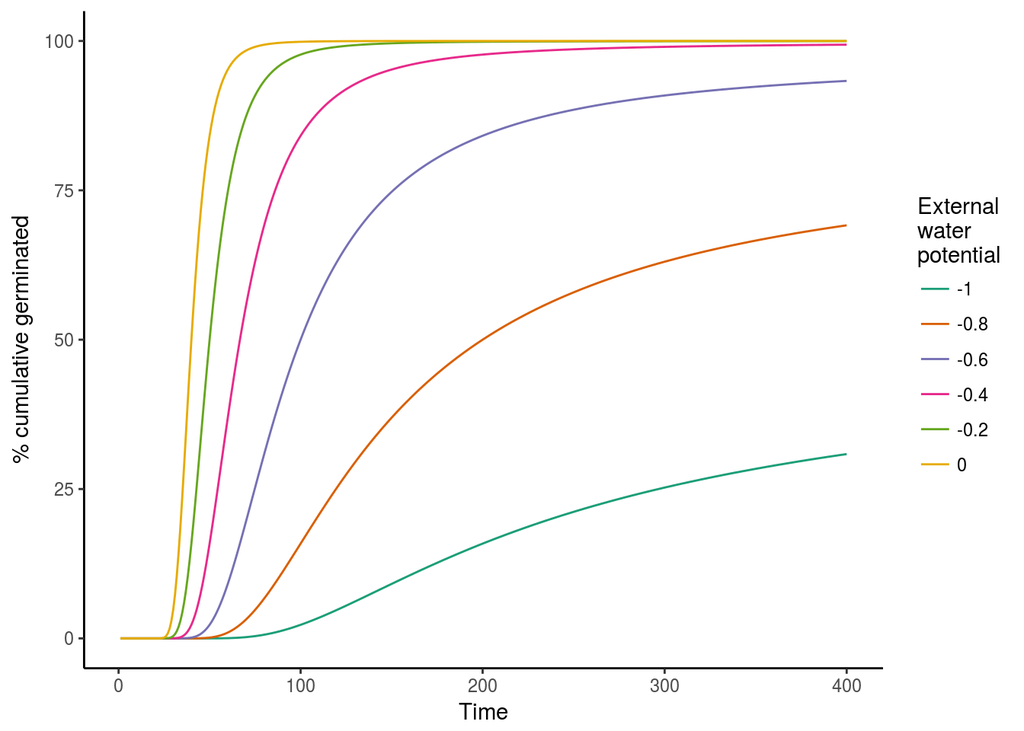

```r
p1 <- x %>%
  ggplot(aes(t, cum_g*100, colour = factor(psi), group = psi)) +
  geom_line() +
  labs(x = "Time", y = "% cumulative germinated", colour = "External\nwater\npotential") +
  theme_classic()
p1
```

This can be expressed as % of lines germinated in each day, which is how we’ve been expressing it for our data:

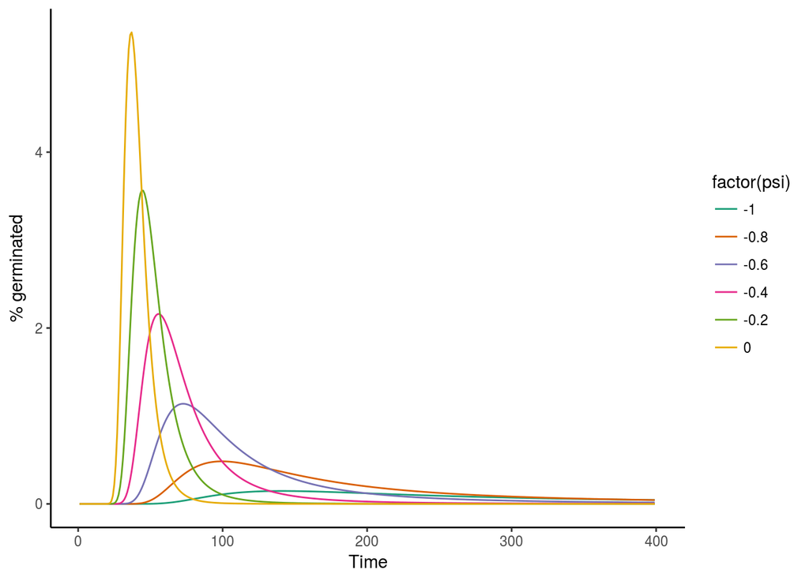

```r
p2 <- x %>%
  ggplot(aes(t, g*100, colour = factor(psi))) +
  geom_line() +
  theme_classic() +
  labs(x = "Time", y = "% germinated")
p2
```

Just to have an idea of the variation associated with each of these distributions, we can estimate the coefficient of variation for each of these distributions, based on some sample size, say 200 seeds:

```r
# Note at this sample size no germination occurs with Psi = -1
x_summary <- x %>%
  mutate(number= round(g*200)) %>%
  rename(day = t) %>%
  group_by(psi) %>%
  filter(!is.na(number)) %>%
  summarise(mean = mean(rep(day, number)),
            mode = mean(day[which(number == max(number))]),
            var =  var(rep(day, number), na.rm=T),
            sd = sqrt(var),
            cv = sd/mean,
            max = max(g*100))
x_summary
```

```
## # A tibble: 6 x 7
##     psi      mean  mode        var        sd        cv       max
##   <dbl>     <dbl> <dbl>      <dbl>     <dbl>     <dbl>     <dbl>
## 1  -1.0       NaN   200         NA        NA        NA 0.1467614
## 2  -0.8 122.00000   122 1036.00000 32.186954 0.2638275 0.4838937
## 3  -0.6  94.45570    79  882.73369 29.710835 0.3145478 1.1387396
## 4  -0.4  68.03867    57  373.53738 19.327115 0.2840607 2.1601465
## 5  -0.2  51.34197    45  152.63245 12.354451 0.2406306 3.5640176
## 6   0.0  40.64646    37   66.49367  8.154365 0.2006168 5.3624672
```

Both figures combined for illustration:

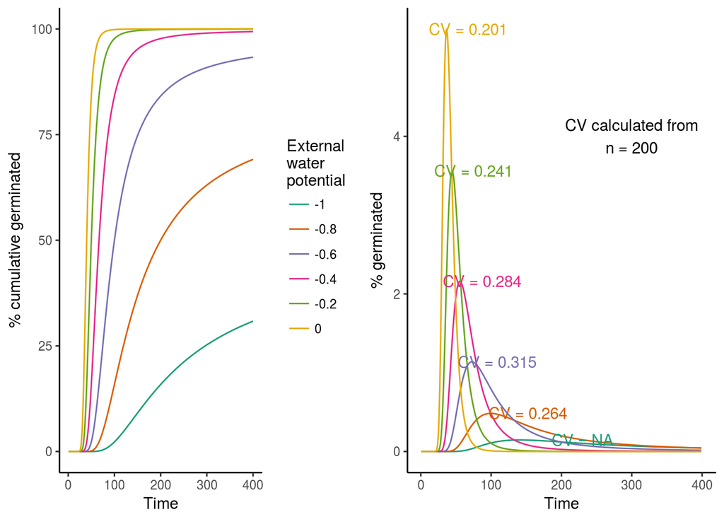

```r
#png("seed_germination_models.png", width = 800, height = 400, res = 100)
gridExtra::grid.arrange(
  p1,
  p2 +
    geom_text(data = x_summary, aes(x = mode + 30, y = max + 0.001, label = paste0("CV = ", round(cv, 3)))) +
    theme(legend.position = "none") +
    annotate(geom = "text", x = 300, y = 4, label = "CV calculated from\nn = 200"),
  ncol = 2
)
```

```r
#dev.off()
```

## Fitting models to data

Let’s now try to fit the seed population models.

First I simulate some data with noise from the above theoretical model. I do this by adding some noise to the probit(g) values (noise from a normal distribution with mean 0):

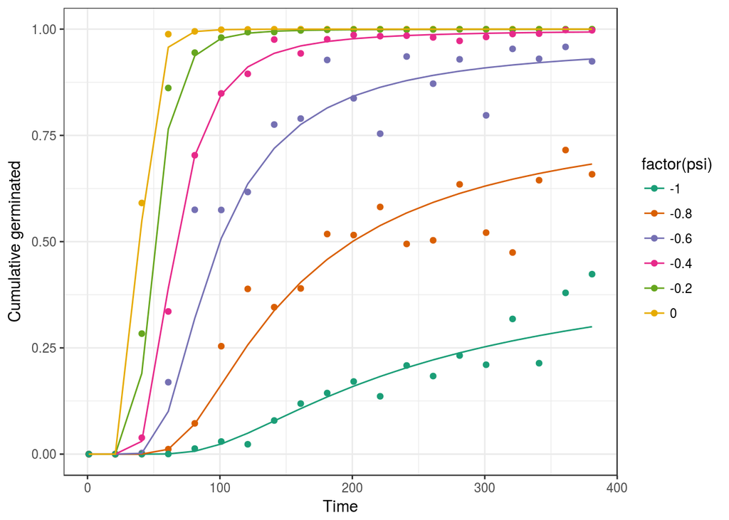

```r
set.seed(1222) # for reproducibility

# Keep only a few time points
## Add some noise to data
test <- x %>%
  filter(t %in% seq(1, 400, 20)) %>%
  #select(t, psi, probitg, g) %>%
  mutate(sim_probitg = probitg + rnorm(n(), sd = 0.25),
         sim_germ = pnorm(sim_probitg))

# Plot in original units
test %>%
  ggplot(aes(t, sim_germ, colour = factor(psi))) +
  geom_point() +
  geom_line(aes(y = cum_g)) +
  labs(x = "Time", y = "Cumulative germinated")
```

Notice that, adding noise to the probit-transformed data actually results in non-homogeneous variance in the original germination scale.

This can also be expressed in probit units, in which case I plot it with regards to the inverse of time (= germination rate), which becomes linear (this property is what makes this transformation useful later when we fit a model to these data):

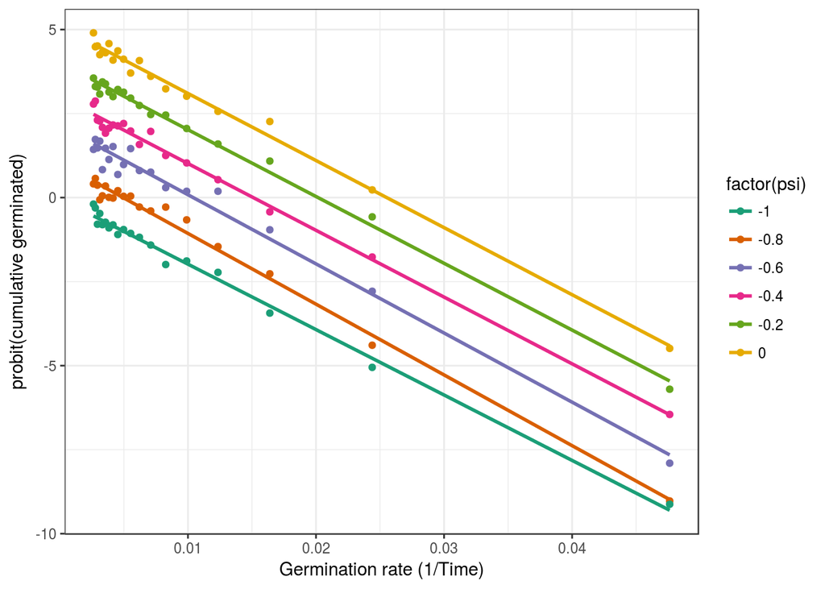

```r
test %>%
  filter(t > 1) %>%
  ggplot(aes(1/t, sim_probitg, colour = factor(psi))) +
  geom_point() +
  stat_smooth(method = "lm", se = FALSE) +
  labs(x = "Germination rate (1/Time)", y = "probit(cumulative germinated)")
```

#### Using `optim` to fit the model

Taking Bradford’s model:

$probit(g) = \frac{X - \frac{\theta}{t} - \overline X_b}{\sigma_{X_b}}$

And plugging it to a function:

```r
# Equation (7) of Bradford 1990 (http://www.plantphysiol.org/content/94/2/840)
modelProbitG <- function(theta, psib50, sigma_psib, psi, t){
  ((psi - theta/t) - psib50)/sigma_psib
}
```

We also define a function that calculates a distance between this model and a fit that will be used with `optim`:

```r
# params = c(theta, psib50, sigma_psib)
modelProbitDist <- function(params, data, y = "sim_probitg", dist_method = c("rmse", "lse")){
  dif <- data[[y]] - modelProbitG(params[1], params[2], params[3], data[["psi"]], data[["t"]])

  # Output root-mean-squared-error
  if(dist_method[1] == "rmse") return(sqrt(mean(dif^2)))

  # Output sum-squared-error
  if(dist_method[1] == "lse") return(sum(dif^2))
}
```

Applying our distance measure using the original (known) parameters, we get a result that is very close to the standard deviation of noise added to the simulated data:

```r
# This is how I'm calculating it in the original data
modelProbitDist(c(40, -1, 0.2), test)
```

```
## [1] 0.2355267
```

So now we can use this with `optim` to find the best-fitting parameters:

```r
test_optim <- optim(c(theta = 0, mean = 0, sigma = 1), modelProbitDist, data = test)
test_optim
```

```
## $par
##      theta       mean      sigma
## 39.2564220 -0.9963883  0.1960412
##
## $value
## [1] 0.2261813
##
## $counts
## function gradient
##      232       NA
##
## $convergence
## [1] 0
##
## $message
## NULL
```

Which is actually not a bad estimate at all!

Below I graph the simulated data, the known curves and fitted curves by this method:

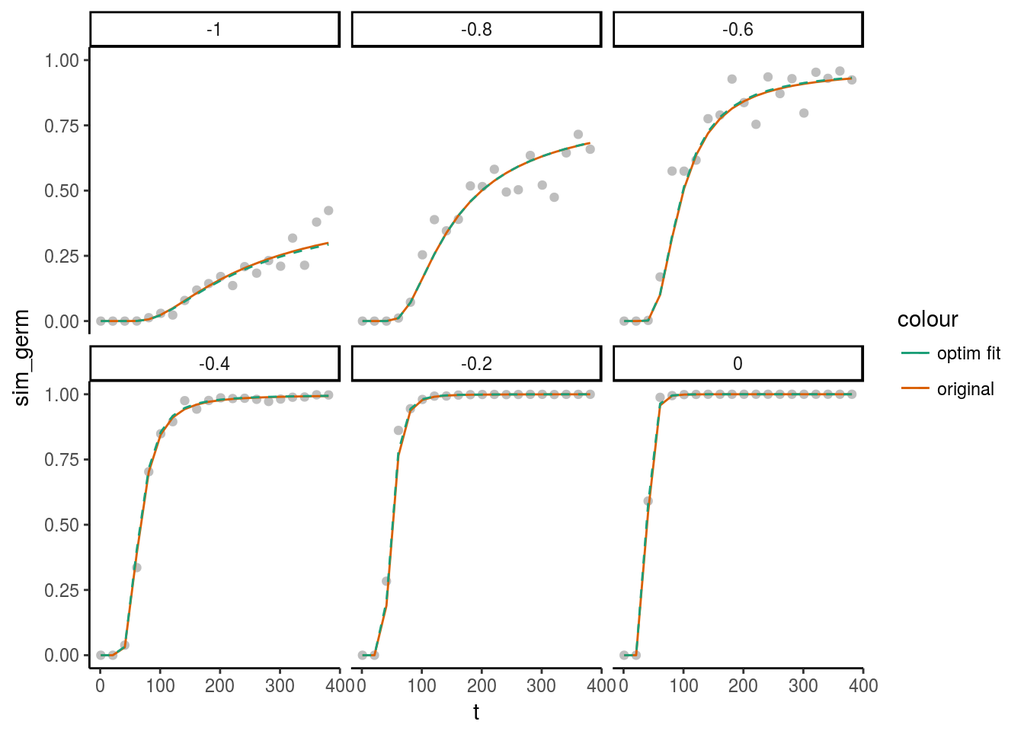

```r
test %>%
  ggplot(aes(t, sim_germ)) +
  geom_point(colour = "grey") +
  geom_line(aes(y = cum_g, colour = "original")) +
  geom_line(aes(y = pnorm(modelProbitG(test_optim$par[1], test_optim$par[2], test_optim$par[3], psi, t)),
                colour = "optim fit"), linetype = "dashed") +
  facet_wrap(~ psi) + theme_classic()
```

#### Using `glm` to fit the model

Using the `glm` function, the model should be expressed in the following way, as demonstrated above:

$probit(g) = - \frac{1}{\sigma_{X_b}} X_b + \frac{1}{\sigma_{X_b}}X - \frac{\theta}{\sigma_{X_b}} \frac{1}{t}$

Which, more simply:

$probit(g) = \mu + \beta_1 X + \beta_2 \frac{1}{t}$

```r
# fit with glm using probit link
test_probit <- glm(sim_germ ~ psi + I(1/t), data = test, family = binomial(link = "probit"))
```

```
## Warning in eval(family$initialize): non-integer #successes in a binomial
## glm!
```

```
## Warning: glm.fit: fitted probabilities numerically 0 or 1 occurred
```

`glm` throws a warning, implying some problem(s). But it still makes a fit, probably by least squares after probit-transforming the data.

The warnings here refer to two things, I think:

- what we did is a wrong specification of the model, at least strictly speaking of how `glm` works. It expects a 0/1 response, or something that can be converted to that kind of response. In this case, we’re giving it cumulative germination, which doesn’t map well to a binary response. We could probably resolve this error by providing some number to the `weights` option, such that the response would become an integer. In real data this might be the total number of seeds assayed at each time point.
- The other warning implies some over-fitting of the model, such that the response was perfectly separated by our independent variables.

As far as a fit is concerned, it’s very close to what was obtained with the `optim` approach:

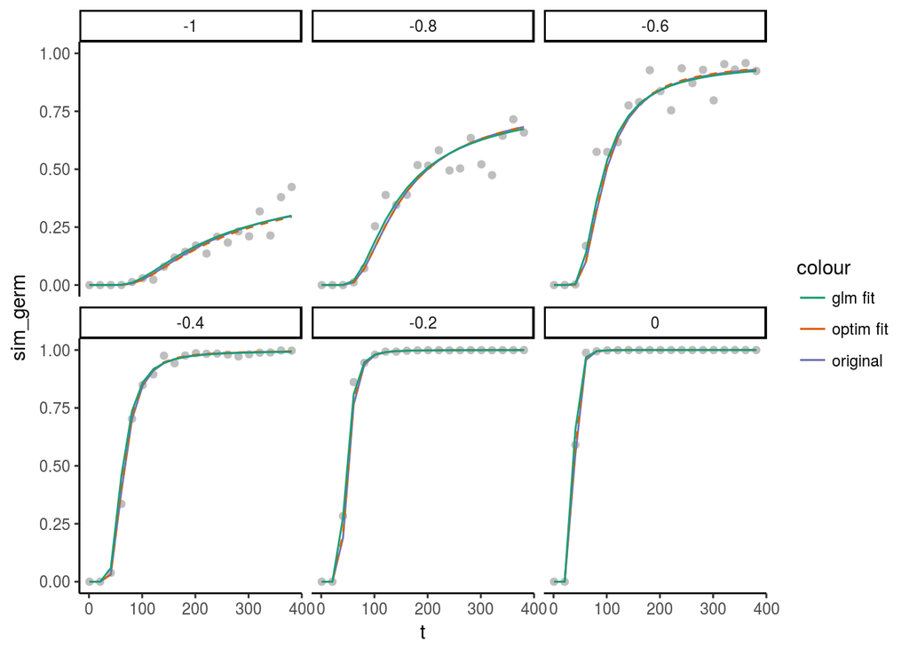

```r
# Get predicted response from model
predict_probit <- test %>%
  mutate(pred = predict(test_probit, type = "response"))

# Plot alongside the original model and optim fit
ggplot(test, aes(t, sim_germ)) +
  geom_point(colour = "grey") +
  geom_line(aes(y = cum_g, colour = "original")) +
  geom_line(aes(y = pnorm(modelProbitG(test_optim$par[1], test_optim$par[2], test_optim$par[3], psi, t)),
                colour = "optim fit"), linetype = "dashed") +
  geom_line(data = predict_probit, aes(y = pred, colour = "glm fit")) +
  facet_wrap(~ psi) + theme_classic()
```

We can convert the coefficient estimates to the “biological” parameters (the convertion is detailed in the first section):

```r
# Function to do this conversion
probitToSeed <- function(mod){
  # sigma = inverse of psi estimate
  Xsigma <- 1/mod$coefficients["psi"]
  names(Xsigma) <- "sigma"

  # theta = -( sigma * 1/t estimate )
  theta <- -(Xsigma * mod$coefficients["I(1/t)"])
  names(theta) <- "theta"

  # mean = -( sigma * intercept )
  Xbar = -(Xsigma * mod$coefficients["(Intercept)"])
  names(Xbar) <- "mean"

  c(theta, Xbar, Xsigma)

}
probitToSeed(test_probit)
```

```
##      theta       mean      sigma
## 37.2698146 -0.9896202  0.2038080
```

For comparison, this is the estimate from the `optim` approach:

```r
test_optim$par
```

```
##      theta       mean      sigma
## 39.2564220 -0.9963883  0.1960412
```

The original parameters:

```r
distinct(x, psib50, sigma_psib, theta)
```

```
## # A tibble: 1 x 3
##   theta psib50 sigma_psib
##   <dbl>  <dbl>      <dbl>
## 1    40     -1        0.2
```

On a linear scale, this is how it looks:

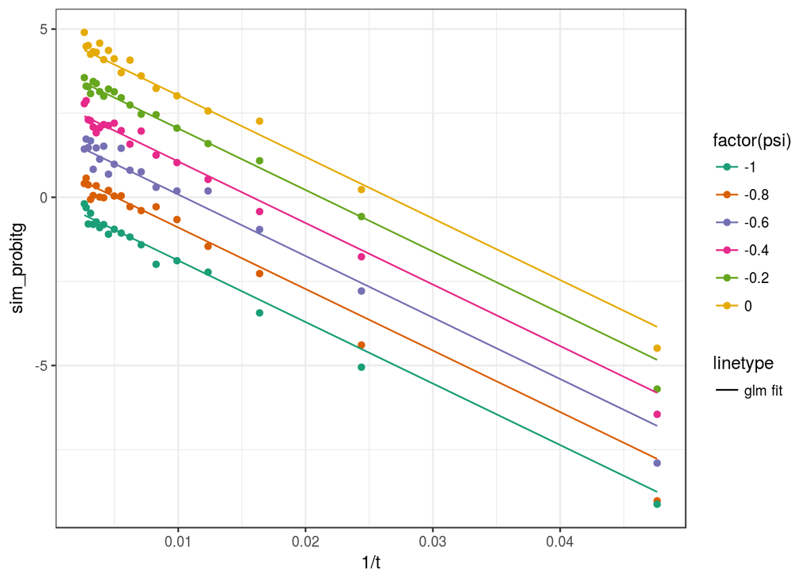

```r
# Note I'm removing time-point 1 to make the plot more visible
test %>%
  mutate(pred = predict(test_probit)) %>%
  filter(t > 1) %>%
  ggplot(aes(1/t, sim_probitg, colour = factor(psi))) +
  geom_point() +
  geom_line(aes(y = pred, linetype = "glm fit"))
```

#### Using `lm` on probit-transformed data

Finally, we can consider to fit a normal linear model to the probit-transformed germination data.

```r
test_lm <- lm(sim_probitg ~ psi + I(1/t), data = test)
```

In this case, to see it on the original scale we have to back-transform the data from this model (back to germination units):

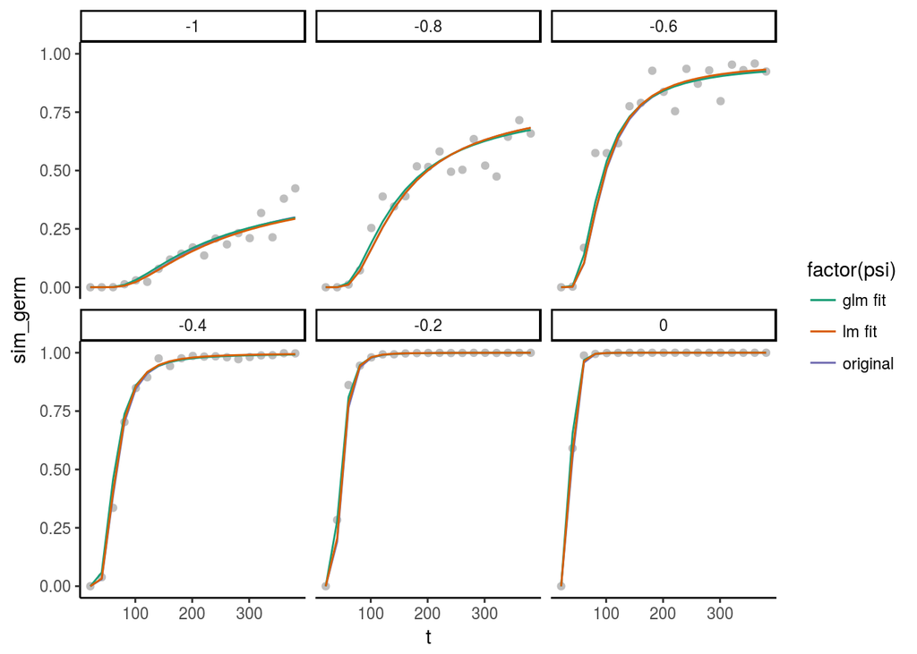

```r
test %>%
  mutate(pred_glm = predict(test_probit, type = "response"),
         pred_lm = pnorm(predict(test_lm))) %>%
  filter(t > 1) %>%
  ggplot(aes(t, sim_germ, colour = factor(psi))) +
  geom_point(colour = "grey") +
  geom_line(aes(y = cum_g, colour = "original")) +
  geom_line(aes(y = pred_glm, colour = "glm fit")) +
  geom_line(aes(y = pred_lm, colour = "lm fit")) +
  facet_wrap(~ psi) + theme_classic()
```

The predictions are slightly different to the `glm` approach, but all quite close to each other:

```r
test_optim$par # optim approach
```

```
##      theta       mean      sigma
## 39.2564220 -0.9963883  0.1960412
```

```r
probitToSeed(test_probit) # glm approach
```

```
##      theta       mean      sigma
## 37.2698146 -0.9896202  0.2038080
```

```r
probitToSeed(test_lm) # lm approach
```

```
##      theta       mean      sigma
## 39.2617138 -0.9964253  0.1960671
```

And finally, we can visualise it on a probit-scale in relation to germination rate (1/t):

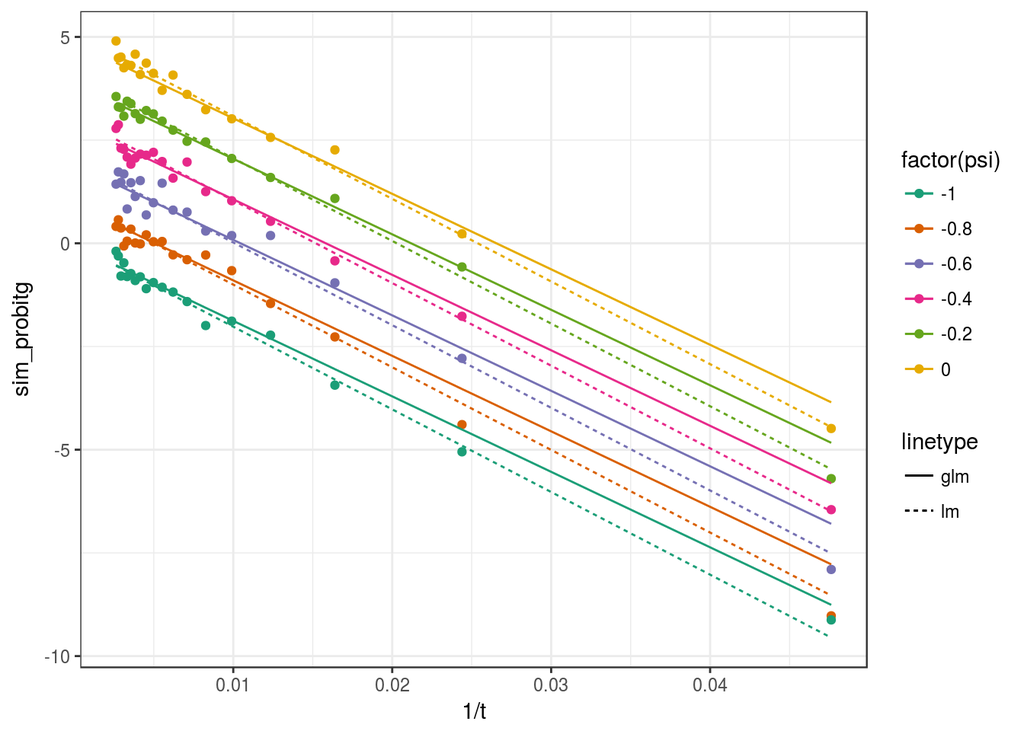

```r
test %>%
  mutate(pred_glm = predict(test_probit),
         pred_lm = (predict(test_lm))) %>%
  filter(t > 1) %>%
  ggplot(aes(1/t, sim_probitg, colour = factor(psi))) +
  geom_point() +
  geom_line(aes(y = pred_glm, linetype = "glm")) +
  geom_line(aes(y = pred_lm, linetype = "lm"))
```

## Conclusions and problems to think about

- all three methods used gave reasonable fits
- `glm` threw some warnings which we should think about
- either `glm` or `lm` approaches seem preferable because they are more stable and allow more flexibility in specifying models - for example, several genotypes can be fit at once (adding another term) and interactions between terms can also be tested

One problem in real data, is how to we deal with the fact that `probit(1) = Inf` and `probit(0) = -Inf`?

In real data we are going to have cases where the cumulative germination is either 0 or 1. In this simulated data, we obtained the probit values from the model, which does not have this problem.

If we use the `glm` approach, this might not be a problem, but if we want to use the `lm` or `optim` approaches, which work on probit-transformed data then we need to address this.